# T3_aed

Rafael Cabrera, Juan Camilo Rodriguez, Guillermo Ribero

25/2/2022

#### 1. Find the maximum likelihood estimates of the $2 \times 1$ mean vector $\mu$ and the $2 \times 2$ covariance matrix $\Sigma$ based on the random sample

$$\mathbf{X}=\left[\begin{array}{ll}
3 & 6 \\
4 & 4 \\
5 & 7 \\
4 & 7
\end{array}\right]$$
from a bivariate normal population.

```r
x1 = c(3,4,5,4)
x2 = c(6,4,7,7)

X = cbind(x1, x2)
n = length(x1)

X_barra = c(mean(x1), mean(x2))

Z = cov(X)*((n-1)/n)
```

##### Solución punto 1

- Estimador para $\mu$ es:

```r
print(X_barra)
```

```
## [1] 4 6
```

- Estimador para $\Sigma$ es

```r
print(Z)
```

```
##      x1   x2
## x1 0.50 0.25
## x2 0.25 1.50
```

#### 2. Using the data

$$\mathbf{X}=\left[\begin{array}{cc}
2 & 12 \\
8 & 9 \\
6 & 9 \\
8 & 10
\end{array}\right]$$

##### (a) Evaluate $T^{2}$, for testing $H_{0}: \mu^{\prime}=[7, \quad 11]$, using the data

```r
x1 = c(2,8,6,8)
x2 = c(12,9,9,10)
n = length(x1)
X= cbind(x1, x2)

X_mu_0 = c(7,11)

X_barra = c(mean(x1), mean(x2))

Z = cov(X)

Z_inv = solve(Z)

T_square = n * (X_barra- X_mu_0)%*%(Z_inv)%*%(X_barra- X_mu_0)
```

El valor de $T^2$ es:

```r
print(T_square)
```

```
##          [,1]
## [1,] 13.63636
```

##### (b) Specify the distribution of $T^{2}$ for the situation in (a).

La distribución de $T^{2}$ es:

$$\frac{(4-1) \cdot 3}{4-1} \cdot F_{2,2} = 3 \cdot F_{2,2}$$

##### (c) Using (a) and (b), test $H_{0}$ at the $\alpha=.05$ level. What conclusion do you reach?

Evaluando $\alpha=.05$ en $a$ tenemos:

```r
p = 0.95
F_2_2 = qf(p, 2,2)

distribution = 3 * F_2_2
```

Dado que $3 \cdot F_{2,2} = 56.999$, y 57 no es menor que 13.6, con un 0.95 de confianza, no rechazamos $H_{0}$.

##### (d) Determine $\Lambda$

```r
x1 = c(2,8,6,8)
x2 = c(12,9,9,10)
n = length(x1)
X= cbind(x1, x2)

X_mu_0 = c(7,11)

X_mu_og = c(6,10)
matriz_mu_og = rbind(X_mu_og,X_mu_og,X_mu_og,X_mu_og)

#sigma_gorro = ((n-1)/n)*cov(X)
sigma_gorro_0 = matrix(data = c(0,0,0,0), nrow = 2, ncol = 2)

matriz_mu_0 = rbind(X_mu_0,X_mu_0,X_mu_0,X_mu_0)

sigma_gorro_0 = t(X - matriz_mu_0) %*% ((X - matriz_mu_0))

sigma_gorro = t(X - matriz_mu_og) %*% ((X - matriz_mu_og))

lambda = (det(sigma_gorro)/det(sigma_gorro_0))^2
lambda
```

```
## [1] 0.03251814
```

##### (e) Using the Wilk’s Lambda (d), calculate $T^{2}$

Despejando lo visto en clase tenemos:

$$T^2 = (\Lambda^{\frac{-2}{n}} - 1 ) \cdot (n-1)$$

Reemplazando lo encontrado en los puntos anteriores:

```r
Tcuad = (lambda^(-2/n) -1 )*(n-1)
print(Tcuad)
```

```
## [1] 13.63636
```

#### 3. Harry Roberts, a naturalist for the Alaska Fish and Game department, studies grizzly bears with the goal of maintaining a healthy population. Measurements on $n=61$ bears provided the following summary statistics:

$$\begin{array}{l|cccccc}
\text { Variable } & \text { Weight }(\mathrm{kg}) & \text { Body length }(\mathrm{cm}) & \text { Neck } & \text { Girth } & \text { Head length } & \text { Head width } \\
\hline \text { Sample } & & & & & & \\
\text { mean } \bar{x} & 95.52 & 164.38 & 55.69 & 93.39 & 17.98 & 31.13
\end{array}$$

```r
alpha = 0.05 #esto porque nos piden 95% de confianza
p = 6
n = 61

X_barra = c(95.52, 164.38, 55.69, 93.39, 17.98, 31.13)

c1 = c(3266.46, 1343.97, 731.54, 1175.5,162.68,238.37)
c2 = c(1343.97,721.91,324.25,537.35,80.17,117.73)
c3 = c(731.54,324.25,179.28,281.17,39.15,56.80)
c4 = c(1175.50,537.35,281.17,474.98,63.73,94.85)
c5 = c(162.68,80.17,39.15,63.73,9.95,13.88)
c6 = c(238.37,117.73,56.80,94.85,13.88,21.26)
S = cbind(c1,c2,c3,c4,c5,c6)
S
```

```
##           c1      c2     c3      c4     c5     c6
## [1,] 3266.46 1343.97 731.54 1175.50 162.68 238.37
## [2,] 1343.97  721.91 324.25  537.35  80.17 117.73
## [3,]  731.54  324.25 179.28  281.17  39.15  56.80
## [4,] 1175.50  537.35 281.17  474.98  63.73  94.85
## [5,]  162.68   80.17  39.15   63.73   9.95  13.88
## [6,]  238.37  117.73  56.80   94.85  13.88  21.26
```

##### (a) Obtain the large sample $95 \%$ simultaneous confidence intervals for the six population mean body measurements.

```r
#Vector de cancelación para variable 1
a = c(1,0,0,0,0,0)

asa = (a%*%S%*%a)[1,1]

fract = (p*(n-1))/(n*(n-p))

a_t_X_b = (a%*%X_barra)[1,1]

F_p_n = qf(1-alpha, p, n-p)

lw_lm = a_t_X_b - sqrt(fract*F_p_n*asa)

up_lm = a_t_X_b + sqrt(fract*F_p_n*asa)

weight_IC = c(lw_lm, up_lm)

#Vector de cancelación para variable 2
a = c(0,1,0,0,0,0)

asa = (a%*%S%*%a)[1,1]

fract = (p*(n-1))/(n*(n-p))

a_t_X_b = (a%*%X_barra)[1,1]

F_p_n = qf(1-alpha, p, n-p)

lw_lm = a_t_X_b - sqrt(fract*F_p_n*asa)

up_lm = a_t_X_b + sqrt(fract*F_p_n*asa)

B_len_IC = c(lw_lm, up_lm)

#Vector de cancelación para variable 3
a = c(0,0,1,0,0,0)

asa = (a%*%S%*%a)[1,1]

fract = (p*(n-1))/(n*(n-p))

a_t_X_b = (a%*%X_barra)[1,1]

F_p_n = qf(1-alpha, p, n-p)

lw_lm = a_t_X_b - sqrt(fract*F_p_n*asa)

up_lm = a_t_X_b + sqrt(fract*F_p_n*asa)

neck_IC = c(lw_lm, up_lm)

#Vector de cancelación para variable 4
a = c(0,0,0,1,0,0)

asa = (a%*%S%*%a)[1,1]

fract = (p*(n-1))/(n*(n-p))

a_t_X_b = (a%*%X_barra)[1,1]

F_p_n = qf(1-alpha, p, n-p)

lw_lm = a_t_X_b - sqrt(fract*F_p_n*asa)

up_lm = a_t_X_b + sqrt(fract*F_p_n*asa)

girth_IC = c(lw_lm, up_lm)

#Vector de cancelación para variable 5
a = c(0,0,0,0,1,0)

asa = (a%*%S%*%a)[1,1]

fract = (p*(n-1))/(n*(n-p))

a_t_X_b = (a%*%X_barra)[1,1]

F_p_n = qf(1-alpha, p, n-p)

lw_lm = a_t_X_b - sqrt(fract*F_p_n*asa)

up_lm = a_t_X_b + sqrt(fract*F_p_n*asa)

H_len_IC = c(lw_lm, up_lm)

#Vector de cancelación para variable 6
a = c(0,0,0,0,0,1)

asa = (a%*%S%*%a)[1,1]

fract = (p*(n-1))/(n*(n-p))

a_t_X_b = (a%*%X_barra)[1,1]

F_p_n = qf(1-alpha, p, n-p)

lw_lm = a_t_X_b - sqrt(fract*F_p_n*asa)

up_lm = a_t_X_b + sqrt(fract*F_p_n*asa)

H_width_IC = c(lw_lm, up_lm)
```

###### Solución 3a

```r
IC_simult = rbind(weight_IC, neck_IC, girth_IC, H_len_IC, H_width_IC)
```

[output not shown]

##### (b) Obtain the large sample $95 \%$ confidence ellipse for mean weight and mean girth.

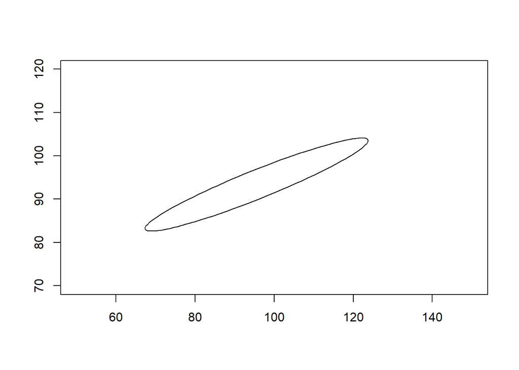

```r
library(plotrix)
X_barra_mini = c(X_barra[1], X_barra[4])

S_mini = matrix(c(S[1,1], S[1,4], S[4,1], S[4,4]), ncol = 2, nrow = 2)
S_mini_data = eigen(S_mini)

lambda1 = S_mini_data$values[1]
lambda2 = S_mini_data$values[2]

e1 = S_mini_data$vectors[,1]
e2 = S_mini_data$vectors[,2]

eje_1 = X_barra_mini + sqrt(lambda1)*sqrt(fract*F_p_n)*e1
eje_2 = X_barra_mini - sqrt(lambda1)*sqrt(fract*F_p_n)*e1
eje_3 = X_barra_mini + sqrt(lambda2)*sqrt(fract*F_p_n)*e2
eje_4 = X_barra_mini - sqrt(lambda2)*sqrt(fract*F_p_n)*e2

#install.packages('plotrix')

angle <- atan(eigen(S_mini)$vectors[2,1]/eigen(S_mini)$vectors[1,1])
plot(0,pch='',ylab='',xlab='',xlim=c(50,150),ylim=c(70,120))
axis1 <- sqrt(eigen(S_mini)$values[1])*
sqrt(
(p*(n-1))/
(n*(n-p))* # no es el mismo valor critico que antes
qf(1-alpha,p,n-p))

axis2 <- sqrt(eigen(S_mini)$values[2])*
sqrt((p*(n-1))/(n*(n-p))*qf(1-alpha,p,n-p))
lengths <- c(axis1,axis2)
draw.ellipse(x=X_barra_mini[1],y=X_barra_mini[2],a=lengths[1],b=lengths[2],angle=angle,deg=FALSE)
```

##### (c) Obtain the $95 \%$ Bonferroni confidence intervals for the six means in Part a.

```r
#Vector de cancelación para variable 1
alpha = 0.05
p = 6
a = c(1,0,0,0,0,0)

asa = (a%*%S%*%a)[1,1]

fract = sqrt(asa/n)

a_t_X_b = (a%*%X_barra)[1,1]

tstudent = qt((1-alpha/(2*p)),df = n-1 )

lw_lm = a_t_X_b - tstudent*fract

up_lm = a_t_X_b + tstudent*fract

weight_IC_c = c(lw_lm, up_lm)

#Vector de cancelación para variable 2
alpha = 0.05
p = 6
a = c(0,1,0,0,0,0)

asa = (a%*%S%*%a)[1,1]

fract = sqrt(asa/n)

a_t_X_b = (a%*%X_barra)[1,1]

tstudent = qt((1-alpha/(2*p)),df = n-1 )

lw_lm = a_t_X_b - tstudent*fract

up_lm = a_t_X_b + tstudent*fract

B_len_IC_c = c(lw_lm, up_lm)

#Vector de cancelación para variable 3
alpha = 0.05
p = 6
a = c(0,0,1,0,0,0)

asa = (a%*%S%*%a)[1,1]

fract = sqrt(asa/n)

a_t_X_b = (a%*%X_barra)[1,1]

tstudent = qt((1-alpha/(2*p)),df = n-1 )

lw_lm = a_t_X_b - tstudent*fract

up_lm = a_t_X_b + tstudent*fract

neck_IC_c = c(lw_lm, up_lm)

#Vector de cancelación para variable 4
alpha = 0.05
p = 6
a = c(0,0,0,1,0,0)

asa = (a%*%S%*%a)[1,1]

fract = sqrt(asa/n)

a_t_X_b = (a%*%X_barra)[1,1]

tstudent = qt((1-alpha/(2*p)),df = n-1 )

lw_lm = a_t_X_b - tstudent*fract

up_lm = a_t_X_b + tstudent*fract

girth_IC_c = c(lw_lm, up_lm)

#Vector de cancelación para variable 5
alpha = 0.05
p = 6
a = c(0,0,0,0,1,0)

asa = (a%*%S%*%a)[1,1]

fract = sqrt(asa/n)

a_t_X_b = (a%*%X_barra)[1,1]

tstudent = qt((1-alpha/(2*p)),df = n-1 )

lw_lm = a_t_X_b - tstudent*fract

up_lm = a_t_X_b + tstudent*fract

H_len_IC_c = c(lw_lm, up_lm)

#Vector de cancelación para variable 6
alpha = 0.05
p = 6
a = c(0,0,0,0,0,1)

asa = (a%*%S%*%a)[1,1]

fract = sqrt(asa/n)

a_t_X_b = (a%*%X_barra)[1,1]

tstudent = qt((1-alpha/(2*p)),df = n-1 )

lw_lm = a_t_X_b - tstudent*fract

up_lm = a_t_X_b + tstudent*fract

H_width_IC_c = c(lw_lm, up_lm)
```

[output not shown]

[figure not shown]

```r
angle <- atan(eigen(S_mini)$vectors[2,1]/eigen(S_mini)$vectors[1,1])
plot(0,pch='',ylab='',xlab='',xlim=c(50,150),ylim=c(70,120))
axis1 <- sqrt(eigen(S_mini)$values[1])*
sqrt(
(p*(n-1))/
(n*(n-p))* # no es el mismo valor critico que antes
qf(1-alpha,p,n-p))

axis2 <- sqrt(eigen(S_mini)$values[2])*
sqrt((p*(n-1))/(n*(n-p))*qf(1-alpha,p,n-p))
lengths <- c(axis1,axis2)
draw.ellipse(x=X_barra_mini[1],y=X_barra_mini[2],a=lengths[1],b=lengths[2],angle=angle,deg=FALSE)
```